# ENRON CORPORATION DETECTIVE

## 1. Project Introduction

In 2000, Enron was one of the largest companies in the United States. By 2002, it had collapsed into bankruptcy due to widespread corporate fraud. In the resulting Federal investigation, there was a significant amount of typically confidential information entered into the public record, including tens of thousands of emails and detailed financial data for top executives. In this project, I will play detective, building a person of interest identifier based on financial and email data made public as a result of the Enron scandal.<sup>[1]</sup>

## 2. Step by step to achieve my goal <sup>[2]</sup>

- Task 0: Import needed library
- Task 1: Support functions
- 1.1 Available support functions
- 1.2 My own support functions
- Task 2: Select what features for using
- Task 3: Remove outliers
- 3.1 Visualize data to find outliers
- 3.2 Remove outliers from data
- Task 4: Prepare new features for learning model
- 4.1 Using cross-validation to split data
- 4.2 Apply Principle Component Analysis (PCA)
- 4.2.1 Reduce dimensionality of data
- 4.2.2 Visualize data after reduced dimensionality
- Task 5: Try a variety of classifiers
- 5.1 Gaussian Naive Bayes
- 5.1.1 Brief Introduction
- 5.1.2 Code
- 5.1.3 Visualization
- 5.2 Support Vector Classification
- 5.2.1 Brief Introduction
- 5.2.2 Code
- 5.2.3 Visualization
- 5.3 Decision Tree
- 5.3.1 Brief Introduction
- 5.3.2 Code
- 5.3.3 Visualization
- 5.4 Adaboost Classifier
- 5.4.1 Brief Introduction
- 5.4.2 Code
- 5.4.3 Visualization
- 5.5 Random Forest Classifier
- 5.5.1 Brief Introduction
- 5.5.2 Code
- 5.5.3 Visualization
- Task 6: Tune classifier to achieve better model
- Task 7: Model Evaluations
- 7.1 Classifier Accuarcy Comparison
- 7.2 Confusion Matrices
- 7.3 Classification Report

## 3. References

[1] https://classroom.udacity.com/courses/ud120/lessons/3335698626/concepts/33363086340923#  
[2] https://classroom.udacity.com/courses/ud120/lessons/3335698626/concepts/33363086340923#  
[3] https://github.com/udacity/ud120-projects/blob/master/tools/feature_format.py  
[4] http://scikit-learn.org/stable/auto_examples/classification/plot_classifier_comparison.html  
[5] http://qingkaikong.blogspot.com/2016/11/machine-learning-6-artificial-neural.html  
[6] http://scikit-learn.org/stable/modules/naive_bayes.html  
[7] https://www.slideshare.net/ashrafmath/naive-bayes-15644818  
[8] http://scikit-learn.org/stable/modules/svm.html#svm-mathematical-formulation  
[9] http://scikit-learn.org/stable/modules/tree.html#tree  
[10] http://scikit-learn.org/stable/modules/ensemble.html#adaboost  
[11] http://www.nickgillian.com/wiki/pmwiki.php/GRT/AdaBoost  
[12] http://scikit-learn.org/stable/modules/ensemble.html#random-forests  
[13] http://amateurdatascientist.blogspot.com/2012/01/random-forest-algorithm.html

## 5. Future work

This is my first project when I firstly took a step toward Machine Learning. I've learned a lot of several excited classifiers, but I do not still go deeper about theory and mathematics of these classifiers, I will dive into it deeper soon because theory and mathematics are beautiful amazing and definitely needed.

# Task 0: Import needed library

```python
### Import libraries
%matplotlib inline
import pickle # Work with hierarchy data file
import itertools # Using product method for calculate confusion matrix
import numpy as np # Numpy array
from matplotlib.ticker import MaxNLocator # Force integer of x-axis and y-axis of confusion matrix
import matplotlib.pyplot as plt # Visualization
from matplotlib.colors import ListedColormap # Content list of color for plotting
from pandas.tools.plotting import scatter_matrix # Visullize matrix of features to compare
from pandas import DataFrame # Convert data to frame of data to visualize
from sklearn.model_selection import train_test_split # Cross-validation for split data
from sklearn.metrics import accuracy_score # Caculate accuracy of every models
from sklearn.metrics import confusion_matrix, classification_report # Model evaluation
from sklearn.naive_bayes import GaussianNB # Gaussian Naive Bayes
from sklearn.decomposition import PCA # Principle Component Analysis
from sklearn.svm import SVC # Support Vector Classification
from sklearn.tree import DecisionTreeClassifier # Decision Tree Classifier
from sklearn.ensemble import AdaBoostClassifier # Adaboost Classifier
from sklearn.ensemble import RandomForestClassifier # Random Forest Classifier
```

# Task 1: Support functions

## 1.1 Available support functions <sup>[3]</sup>

```python
### Available support functions
#1. Feature format function
def featureFormat( dictionary, features,
                  remove_NaN=True,
                  remove_all_zeroes=True,
                  remove_any_zeroes=False,
                  sort_keys = False):
    """ convert dictionary to numpy array of features
        remove_NaN = True will convert "NaN" string to 0.0
        remove_all_zeroes = True will omit
            any data points for which
            all the features you seek are 0.0
        remove_any_zeroes = True will omit
            any data points for which
            any of the features you seek are 0.0
        sort_keys = True sorts keys by alphabetical order.
            Setting the value as a string opens the
            corresponding pickle file with a preset key
            order (this is used for Python 3 compatibility,
            and sort_keys should be left as False for
            the course mini-projects).
        NOTE: first feature is assumed to be 'poi' and
            is not checked for removal for zero
            or missing values.
    """
    return_list = []

    # Key order - first branch is for Python 3 compatibility on mini-projects,
    # second branch is for compatibility on final project.
    if isinstance(sort_keys, str):
        import pickle
        keys = pickle.load(open(sort_keys, "rb"))
    elif sort_keys:
        keys = sorted(dictionary.keys())
    else:
        keys = dictionary.keys()

    for key in keys:
        tmp_list = []
        for feature in features:
            try:
                dictionary[key][feature]
            except KeyError:
                print "error: key ", feature, " not present"
                return
            value = dictionary[key][feature]
            if value=="NaN" and remove_NaN:
                value = 0
            tmp_list.append( float(value) )

        # Logic for deciding whether or not to add the data point.
        append = True
        # exclude 'poi' class as criteria.
        if features[0] == 'poi':
            test_list = tmp_list[1:]
        else:
            test_list = tmp_list
        ### if all features are zero and you want to remove
        ### data points that are all zero, do that here
        if remove_all_zeroes:
            append = False
            for item in test_list:
                if item != 0 and item != "NaN":
                    append = True
                    break
        ### if any features for a given data point are zero
        ### and you want to remove data points with any zeroes,
        ### handle that here
        if remove_any_zeroes:
            if 0 in test_list or "NaN" in test_list:
                append = False
        ### Append the data point if flagged for addition.
        if append:
            return_list.append( np.array(tmp_list) )

    return np.array(return_list)

#2. Target features split function
def targetFeatureSplit( data ):
    """
        given a numpy array like the one returned from
        featureFormat, separate out the first feature
        and put it into its own list (this should be the
        quantity you want to predict)

        return targets and features as separate lists

        (sklearn can generally handle both lists and
        numpy arrays as input formats when
        training/predicting)
    """

    target = []
    features = []
    for item in data:
        target.append( item[0] )
        features.append( item[1:] )

    return target, features
```

## 1.2 My own support functions <sup>[4][5]</sup>

```python
### My own support functions
#1. Clean outliers
def outliersCleaner(features, labels):
    """
    This function clean outliers from original data
    """
    # Convert to list of features + labels
    data_set = zip(features, labels)

    #Sort it to find outliers
    features_sorted = list(data_set)
    features_sorted.sort(key = lambda column: column[0][0])

    # After observation, removed 43 outliers from data
    features_sorted = list(features_sorted[:130])
    features_sorted.sort(key = lambda column: column[0][0])
    features_sorted = list(features_sorted[:120])
    features_sorted.sort(key = lambda column: column[0][2])
    features_sorted = list(features_sorted[:110])
    features_sorted.sort(key = lambda column: column[0][3])
    features_sorted = list(features_sorted[:100])

    #Split into original features and labels
    cleaned_features = [features[0] \
                        for features in features_sorted]
    cleaned_labels = [labels[1] \
                      for labels in features_sorted]

    return cleaned_features, cleaned_labels

#2. Visualize model[4]
def visualizeModel(clf, X_train, y_train,
                   X_test, y_test, model_names):
    """
    This function visualizes predicted models
    """
    #Config size of plot
    plt.figure(figsize=(7,7))

    # Plot the decision boundary. For that,
    # we will assign a color to each
    # point in the mesh [x_min, m_max]x[y_min, y_max].
    x_min, x_max = X_train[:, 0].min() - .5, \
                   X_train[:, 0].max() + .5
    y_min, y_max = X_train[:, 0].min() - .5, \
                   X_train[:, 0].max() + .5

    #Step size in the mesh
    h = 0.01
    xx, yy = np.meshgrid(np.arange(x_min, x_max, h),
                         np.arange(y_min, y_max, h))
    Z = clf.predict(np.c_[xx.ravel(), yy.ravel()])

    #Crete color for training point and test point
    cm = plt.cm.RdBu
    cm_bright = ListedColormap(['#FF0000', '#0000FF'])
    cm_bright_test =ListedColormap(['',''])

    # Predict meshg rid point to assign color
    #Z = clf.predict(np.c_[xx.ravel(), yy.ravel()])
    score = clf.score(X_test, y_test)
    if hasattr(clf, "decision_function"):
        Z = clf.decision_function(np.c_[xx.ravel(), yy.ravel()])
    else:
        Z = clf.predict_proba(np.c_[xx.ravel(), yy.ravel()])[:, 1]

    # Put the result into a color plot
    Z = Z.reshape(xx.shape)
    plt.xlim(xx.min(), xx.max())
    plt.ylim(yy.min(), yy.max())

    #Plot the features_train point and features_test point
    plt.contourf(xx, yy, Z, cmap=cm, alpha=.9)
    plt.scatter(X_train[:, 0], X_train[:, 1],
                c=y_train, cmap=cm_bright)
    plt.scatter(X_test[:, 0], X_test[:, 1],
                c=y_test, cmap=cm_bright, alpha=0.4)

    #Also plot the legend
    plt.scatter(0, 0, color = 'r', label='train point_[0]')
    plt.scatter(0, 0, color = 'b', label='train point_[1]')
    plt.scatter(0, 0, color = 'r', label='test point_[0]', alpha=.4)
    plt.scatter(0, 0, color = 'b', label='test point_[1]', alpha=.4)
    plt.legend()

    #Plot the accuracy for this model
    plt.text(xx.max() - .3,
             yy.min() + .3,('%.2f' % score).lstrip('0'),
             size=15, horizontalalignment='right', color='w')

    #Plot the name of model
    plt.title(model_names)

    #Show plot
    plt.show()

#3. Plot confusion matrix[5]
def plotConfusionMatrix(names, classifiers,
                        X_train, y_train,
                        X_test, y_test):
    """
    This function prints and plots the confusion matrix.
    """
    #Figure size of plot
    step = 1
    plt.figure(figsize=(16,16))

    #Plot each of sub confusion matrix
    for name, clf in zip(names, classifiers):
        clf.fit(X_train, y_train)
        pred = clf.predict(X_test)
        cm = confusion_matrix(y_test, pred)
        #Create subplot
        ax = plt.subplot(1, len(classifiers), step)
        #Force value of x and y axis to integer
        ax.xaxis.set_major_locator(MaxNLocator(integer=True))
        ax.yaxis.set_major_locator(MaxNLocator(integer=True))

        ax.imshow(cm, interpolation='nearest', cmap=plt.cm.Blues)
        thresh = cm.max() / 1.5
        for i, j in itertools.product(range(cm.shape[0]),
                                      range(cm.shape[1])):
            ax.text(j, i, cm[i, j],
                    horizontalalignment="center",
                    color="white" if cm[i, j] > thresh else "black")
        ax.set_ylabel('True label')
        ax.set_xlabel('Predicted label')
        ax.set_title(name)
        step += 1

    #Show plot
    plt.tight_layout()
    plt.show()

#4. Plot Classifier Accuracy Comparison
def plotAccuaracyComparison(acc):
    sorted_acc = sorted(acc.items(), key=lambda x: x[1])
    x_pos = np.arange(len(sorted_acc))

    names = zip(*sorted_acc)[0]
    values = zip(*sorted_acc)[1]

    plt.figure(figsize=(7,7))
    bar_list = plt.bar(x_pos, values , align='center')
    plt.xticks(x_pos, names)
    plt.title('Classifier Accuracy Comparison Chart')
    bar_list[len(names) - 1].set_color('r')
    plt.show()

#5. Plot Classification Report
def plotClassificationReport(names, classifiers,
                             X_train, y_train,
                             X_test, y_test):
    #Figure size of plot
    step = 1
    plt.figure(figsize=(16,16))

    #Set information for x-axis
    axis = np.arange(3)
    axis_names = ['Precision', 'Recall', 'F1-Score']

    #Plot each of sub confusion matrix
    for name, clf in zip(names, classifiers):
        clf.fit(X_train, y_train)
        pred = clf.predict(X_test)
        #Caculate classification report
        cr = classification_report(y_test, pred)
        lines = cr.split('\n')

        #Split score from original confusion matrices
        scores_set = []
        for line in lines[2 : (len(lines) - 3)]:
            tmp = line.split()
            score = [float(item) \
                     for item in tmp[1: len(tmp) - 1]]
            scores_set.append(score)

        ax = plt.subplot(1, len(classifiers), step)

        ax.xaxis.set_major_locator(MaxNLocator(integer=True))
        ax.yaxis.set_major_locator(MaxNLocator(integer=True))

        scores_set = np.reshape(scores_set, (2, 3))

        ax.imshow(scores_set, interpolation='nearest', \
                  cmap=plt.cm.Blues)

        thresh = scores_set.max() / 2.2
        for i, j in itertools.product(range(scores_set.shape[0]),
                                      range(scores_set.shape[1])):
            ax.text(j, i, scores_set[i, j],
                    horizontalalignment="center",
                    color="white" if scores_set[i, j] > thresh else "black")
        ax.set_title(name)
        plt.xticks(axis, axis_names)
        step += 1

    #Show plot
    plt.tight_layout()
    plt.show()
```

# Task 2: Select what features for using

```python
### Task 1: Select what features for using
### features_list is a list of strings, each of which is a feature name.
### The first feature must be "poi".
features_list = ['poi','salary', 'bonus',
                 'total_payments',
                 'total_stock_value']

### Load the dictionary containing the dataset
part1_url = '/home/truong/Downloads/ud120-projects-master/'
part2_url = 'final_project/final_project_dataset.pkl'
file_url = part1_url + part2_url
with open(file_url, 'r') as data_file:
    data_dict = pickle.load(data_file)
```

# Task 3: Remove outliers

### 3.1 Visualize data to find outliers

```
                   Data before removing outliers
```

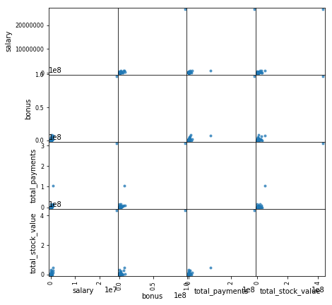

```python
### Task 3.1: Visualize data to find outliers
data = featureFormat(data_dict,
                     features_list, sort_keys = False)
labels, features = targetFeatureSplit(data)
df = DataFrame(features, columns=['salary', 'bonus',
                                  'total_payments',
                                  'total_stock_value'])
scatter_matrix(df, alpha=0.7,
               figsize=(7, 7),diagonal=None)
print '                   Data before removing outliers'
plt.show()
```

### 3.2 Remove outliers from data

```
                   Data after removing outliers
```

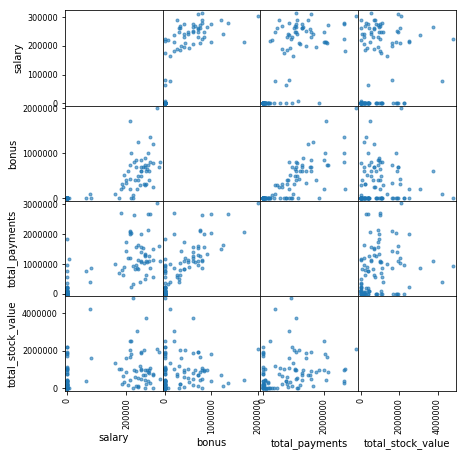

```python
### Task 3.2: Remove 43 outliers from data
cleaned_features, cleaned_labels = \
                    outliersCleaner(features, labels)
df = DataFrame(cleaned_features, columns=['salary', 'bonus',
                                          'total_payments',
                                          'total_stock_value'])
scatter_matrix(df, alpha=0.6,
               figsize=(7, 7), diagonal=None)
print '                   Data after removing outliers'
plt.show()
```

# Task 4: Prepare new features for learning model

## 4.1 Using cross-validation to split data

```python
### Task 4.1: Prepare features_train, features_test
### labels_train, labels_test for learning using Cross-Validation
### 60 % for training and 40 % for test, all of them randomly
### with random state = 42
features_train, features_test, labels_train, labels_test = \
    train_test_split(cleaned_features, cleaned_labels,
                     test_size = 0.4, random_state=42)
```

Cross-Validation Theory

[figure not shown]

[https://www.researchgate.net/figure/260399256_fig4_Fig-4-Differential-Evolution-based-cross-validation-process]

## 4.2 Apply Principle Component Analysis (PCA)

### 4.2.1 Reduce dimensionality of data

```python
### Task 4.2.1: Reduce dimensionality of data
### from 4 features to 2 principle components
pca = PCA(svd_solver='randomized', n_components=2,
          whiten=True).fit(features_train)
features_train_pca = pca.transform(features_train)
features_test_pca = pca.transform(features_test)
```

### 4.2.2 Visualize data after reduced dimensionality

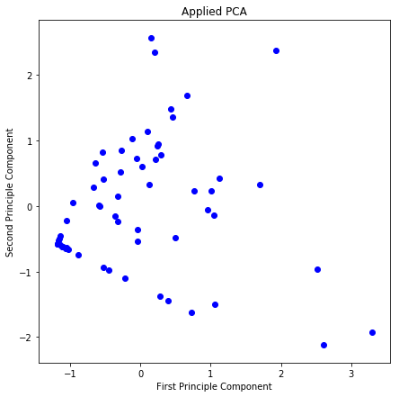

```python
### Task 4.2.2: Visualize data after reduce dimensionality
plt.figure(figsize=(7,7))
for feature in features_train_pca:
    plt.scatter(feature[0], feature[1], color='b')
plt.xlabel('First Principle Component')
plt.ylabel('Second Principle Component')
plt.title('Applied PCA')
plt.show()
```

# Task 5: Try a variety of classifiers

## 5.1 Gaussian Naive Bayes

### 5.1.1 Theory

A brief glimpse <sup>[6]</sup>  
Naive Bayes methods are a set of supervised learning algorithms based on applying Bayes’ theorem with the “naive” assumption of independence between every pair of features. Given a class variable $y$ and a dependent feature vector $x_1$ through $x_n$, Bayes’ theorem states the following relationship:

[figure not shown]

Using the naive independence assumption that

[figure not shown]

for all i, this relationship is simplified to

[figure not shown]

GaussianNB implements the Gaussian Naive Bayes algorithm for classification. The likelihood of the features is assumed to be Gaussian:

[figure not shown]

Advantages and Disadvantages of Naive Bayes <sup>[7]</sup>  
Advantages:

- Easy to implement
- Requires small amount of data to estimate the parameters
- Good results obtained in most of the cases

Disadvantages:

- Assumption: class conditional independence, therefore lost accuracy
- Practically, dependencies exist among variables
- Dependencies can not be modeled by Naive Bayes Classifier

### 5.1.2 Code

```python
### Gaussian Naive Bayes
clf = GaussianNB()
clf.fit(features_train_pca, labels_train)
print
```

### 5.1.3 Visualization

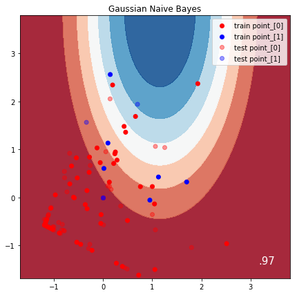

```python
model_names = 'Gaussian Naive Bayes'
visualizeModel(clf, features_train_pca, labels_train,
               features_test_pca, labels_test,
               model_names=model_names)
```

## 5.2 Support Vector Classification

### 5.2.1 Theory<sup>[8]</sup>

A brief glimpse about SVM  
A support vector machine constructs a hyper-plane or set of hyper-planes in a high or infinite dimensional space, which can be used for classification, regression or other tasks. Intuitively, a good separation is achieved by the hyper-plane that has the largest distance to the nearest training data points of any class (so-called functional margin), since in general the larger the margin the lower the generalization error of the classifier.

[figure not shown]

Advantages and Disadvantages of SVM  
Advantages:

- Effective in high dimensional spaces
- Still effective in cases where number of dimensions is greater than the number of samples
- Uses a subset of training points in the decision function (called support vectors), so it is also memory efficient
- Versatile: different Kernel functions can be specified for the decision function. Common kernels are provided, but it is also possible to specify custom kernels

Disadvantages:

- If the number of features is much greater than the number of samples, the method is likely to give poor performances
- SVMs do not directly provide probability estimates, these are calculated using an expensive five-fold cross-validation

### 5.2.2 Code

```python
### Support Vector Classification
clf = SVC()
clf.fit(features_train_pca, labels_train)
print
```

### 5.2.3 Visualization

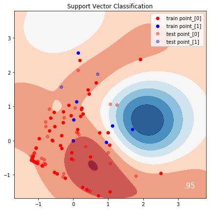

```python
model_names = 'Support Vector Classification'
visualizeModel(clf, features_train_pca, labels_train,
               features_test_pca, labels_test,
               model_names=model_names)
```

## 5.3 Decision Tree

### 5.3.1 Theory <sup>[9]</sup>

A brief glimpse  
Trees are a non-parametric supervised learning method used for classification and regression. The goal is to create a model that predicts the value of a target variable by learning simple decision rules inferred from the data features.

[figure not shown]

Advantages and Disadvantages of Decision Tree  
Advantages:

- Simple to understand and to interpret. Trees can be visualized
- Requires little data preparation. Other techniques often require data normalization, dummy variables need to be created and blank values to be removed
- Able to handle both numerical and categorical data
- Able to handle multi-output problems

Disadvantages:

- Decision-tree learners can create over-complex trees that do not generalize the data well. This is called overfitting
- Decision trees can be unstable because small variations in the data might result in a completely different tree being generated

### 5.3.2 Code

```python
clf = DecisionTreeClassifier()
clf.fit(features_train_pca, labels_train)
print
```

### 5.3.3 Visualization

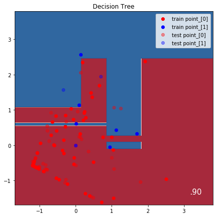

```python
model_names = 'Decision Tree'
visualizeModel(clf, features_train_pca, labels_train,
               features_test_pca, labels_test,
               model_names=model_names)
```

## 5.4 AdaBoost Classifier

### 5.4.1 Theory

A brief glimpse<sup>[10]</sup>  
The core principle of AdaBoost is to fit a sequence of weak learners (i.e., models that are only slightly better than random guessing, such as small decision trees) on repeatedly modified versions of the data. The predictions from all of them are then combined through a weighted majority vote (or sum) to produce the final prediction. The data modifications at each so-called boosting iteration consist of applying weights $w_1$, $w_2$, ..., $w_N$ to each of the training samples

[figure not shown]

[http://www.ieev.org/2010/03/adaboost-haar-features-face-detection_22.html]

Advantages and Disadvantages of AdaBoost Classifier <sup>[11]</sup>  
Advantages:

- Unlike other powerful classifiers, such as SVM, AdaBoost can achieve similar classification results with much less tweaking of parameters or settings

Disadvantages:

- AdaBoost can be sensitive to noisy data and outliers

### 5.4.2 Code

```python
clf = AdaBoostClassifier()
clf.fit(features_train_pca, labels_train)
print
```

### 5.4.3 Visualization

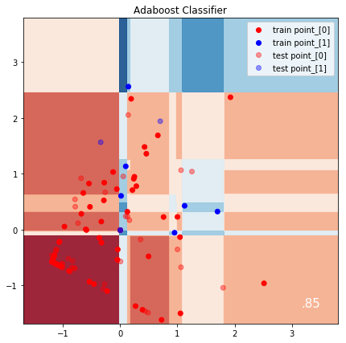

```python
model_names = 'Adaboost Classifier'
visualizeModel(clf, features_train_pca, labels_train,
               features_test_pca, labels_test,
               model_names=model_names)
```

## 5.5 Random Forest Classifier

### 5.5.1 Theory

A brief glimpse<sup>[12]</sup>  
In Random Forest, each tree in the ensemble is built from a sample drawn with replacement (i.e., a bootstrap sample) from the training set. In addition, when splitting a node during the construction of the tree, the split that is chosen is no longer the best split among all features. Instead, the split that is picked is the best split among a random subset of the features. As a result of this randomness, the bias of the forest usually slightly increases (with respect to the bias of a single non-random tree) but, due to averaging, its variance also decreases, usually more than compensating for the increase in bias, hence yielding an overall better model.

[figure not shown]

[https://www.youtube.com/watch?v=ajTc5y3OqSQ]

Advantages and Disadvantages of Random Forest Classifier <sup>[13]</sup>  
Advantages:

- It is one of the most accurate learning algorithms available. For many data sets, it produces a highly accurate classifier
- It runs efficiently on large databases
- It can handle thousands of input variables without variable deletion

Disadvantages:

- Random forests have been observed to overfit for some datasets with noisy classification/regression tasks

### 5.5.2 Code

```python
clf = RandomForestClassifier()
clf.fit(features_train_pca, labels_train)
print
```

### 5.5.3 Visualization

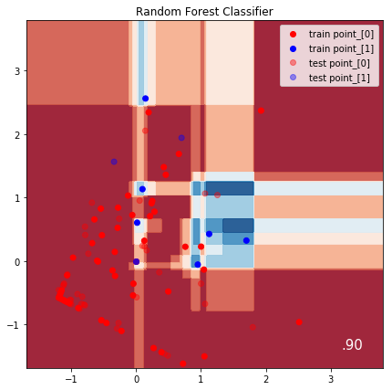

```python
model_names = 'Random Forest Classifier'
visualizeModel(clf, features_train_pca, labels_train,
               features_test_pca, labels_test,
               model_names=model_names)
```

# Task 6: Tune classifier parameter to achieve better model

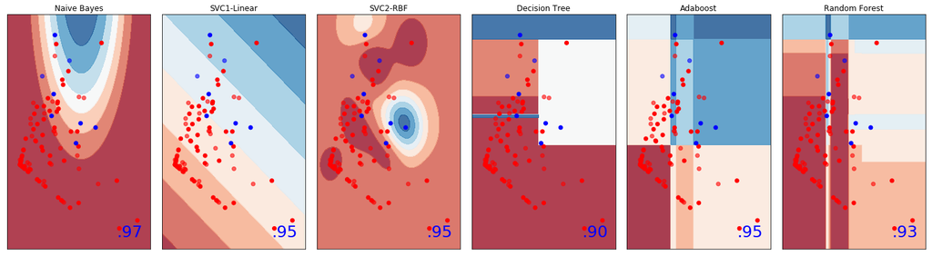

```python
### Task 6: Tune classifier to achieve better than the previous task
names = ['Naive Bayes', 'SVC1-Linear',
         'SVC2-RBF', 'Decision Tree',
         'Adaboost', 'Random Forest']
classifiers = [GaussianNB(),
               SVC(kernel="linear", C=0.025),
               SVC(gamma=2, C=0.0025),
               DecisionTreeClassifier(min_samples_split=10),
               AdaBoostClassifier(n_estimators=100,
                                  learning_rate=0.025),
               RandomForestClassifier(n_estimators=10,
                                      max_features=2,
                                      min_samples_split=8)]

h = .01  # step size in the mesh

cm = plt.cm.RdBu
cm_bright = ListedColormap(['#FF0000', '#0000FF'])

x_min, x_max = features_train_pca[:, 0].min() - .5, \
               features_train_pca[:, 0].max() + .5
y_min, y_max = features_train_pca[:, 1].min() - .5, \
               features_train_pca[:, 1].max() + .5
xx, yy = np.meshgrid(np.arange(x_min, x_max, h),
                     np.arange(y_min, y_max, h))

#Caculate accuracy for another task
acc = {}

figure = plt.figure(figsize=(20, 16))
i = 1
for name, clf in zip(names, classifiers):
    ax = plt.subplot(3, len(classifiers), i)
    clf.fit(features_train_pca, labels_train)
    score = clf.score(features_test_pca, labels_test)

    #Caculate accuracy for plotting in next task
    acc.update({name: score * 100})

    # Plot the decision boundary. For that, we will assign a color
    # to each point in the mesh [x_min, x_max]x[y_min, y_max].
    if hasattr(clf, "decision_function"):
        Z = clf.decision_function(np.c_[xx.ravel(),
                                        yy.ravel()])
    else:
        Z = clf.predict_proba(np.c_[xx.ravel(),
                                    yy.ravel()])[:, 1]

    # Put the result into a color plot
    Z = Z.reshape(xx.shape)
    ax.contourf(xx, yy, Z, cmap=cm, alpha=.8)

    # Plot also the training points
    ax.scatter(features_train_pca[:, 0],
               features_train_pca[:, 1],
               c=labels_train, cmap=cm_bright)
    # and testing points
    ax.scatter(features_test_pca[:, 0],
               features_test_pca[:, 1],
               c=labels_test, cmap=cm_bright,
               alpha=0.6)

    ax.set_xlim(xx.min(), xx.max())
    ax.set_ylim(yy.min(), yy.max())

    ax.set_xticks(())
    ax.set_yticks(())
    ax.set_title(name)
    ax.text(xx.max() - .3, yy.min() + .3,
            ('%.2f' % score).lstrip('0'),
            size=25, horizontalalignment='right',
            color = 'b')
    i += 1
#Show plot
plt.tight_layout()
plt.show()
```

# Task 7: Model evaluation

## 7.1 Classifier Accuracy Comparison

[figure not shown]

```python
#Plotting to compare the accuracy of each model
plotAccuaracyComparison(acc)
```

## 7.2 Confusion Matrices

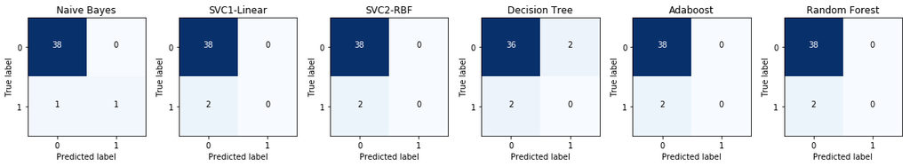

```python
#Plot confusion matrices
plotConfusionMatrix(names, classifiers,
                    features_train_pca, labels_train,
                    features_test_pca, labels_test)
```

## 7.3 Classification Report

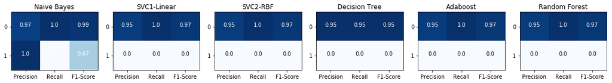

```python
#Plot classification report
plotClassificationReport(names, classifiers,
                         features_train_pca, labels_train,
                         features_test_pca, labels_test)
```